# MITB Capstone Project

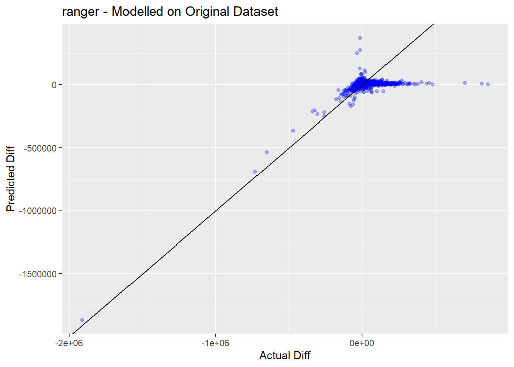

```r
ranger_predVsActual_org
```

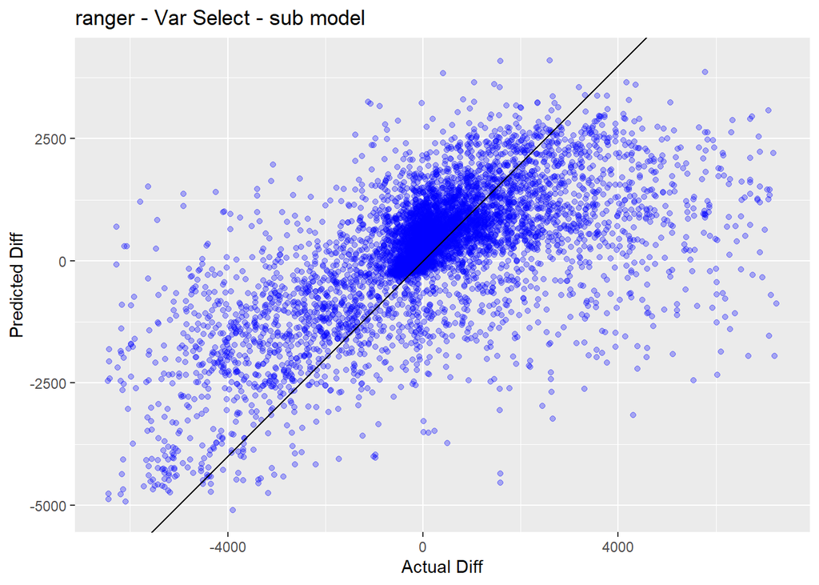

```r
ranger_predVsActual_20wk
```

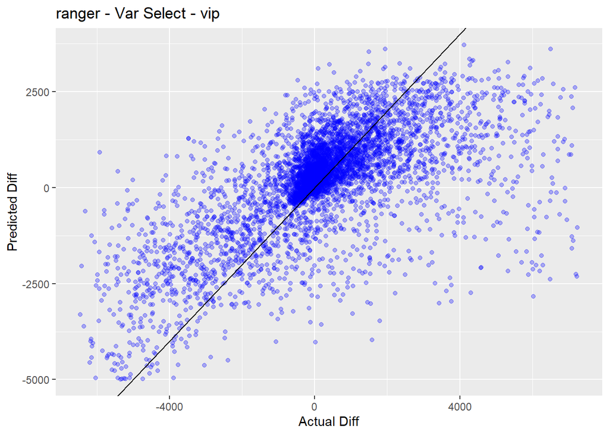

```r
ranger_predVsActual_vip
```

If the model is predicting accurately, all the points will be on the black line. If the points are above the lines, it means the data points are overpredicted. If the points are below the line, it means the predicted value is lower than the actual value.

## 3.4 Partial Regression Plot

### 3.4.1 Without Claim Descriptions

[This](https://community.rstudio.com/t/how-to-use-pdp-partial-in-tidymodels/69735/2) is similar to the [prediction profiler options](https://www.jmp.com/support/help/en/15.2/index.shtml#page/jmp/prediction-profiler-options.shtml) in JMP Pro.

To plot out the partial regression plot

```r
ranger_fit_pdp <- fit(ranger_final_wf, df_train)
```

Create two variable lists to separate numeric and categorical variables

```r
# Numeric variables
num_var_list <- df_train %>%
  select_if(is.numeric) %>%
  dplyr::select(-init_ult_diff) %>%
  names()

# Categorical variables
cat_var_list <- df_train %>%
  select_if(negate(is.numeric)) %>%
  dplyr::select(-c(DateTimeOfAccident, DateReported)) %>%
  names() %>%
  append(c("DateTimeOfAccident_year",
           "DateTimeOfAccident_month",
           "DateTimeOfAccident_dow",
           "DateTimeOfAccident_hr"))
```

#### 3.4.1.1 Numeric variables

Plotting out the numeric variables

```
## Note: Using an external vector in selections is ambiguous.
## i Use `all_of(i)` instead of `i` to silence this message.
## i See <https://tidyselect.r-lib.org/reference/faq-external-vector.html>.
```

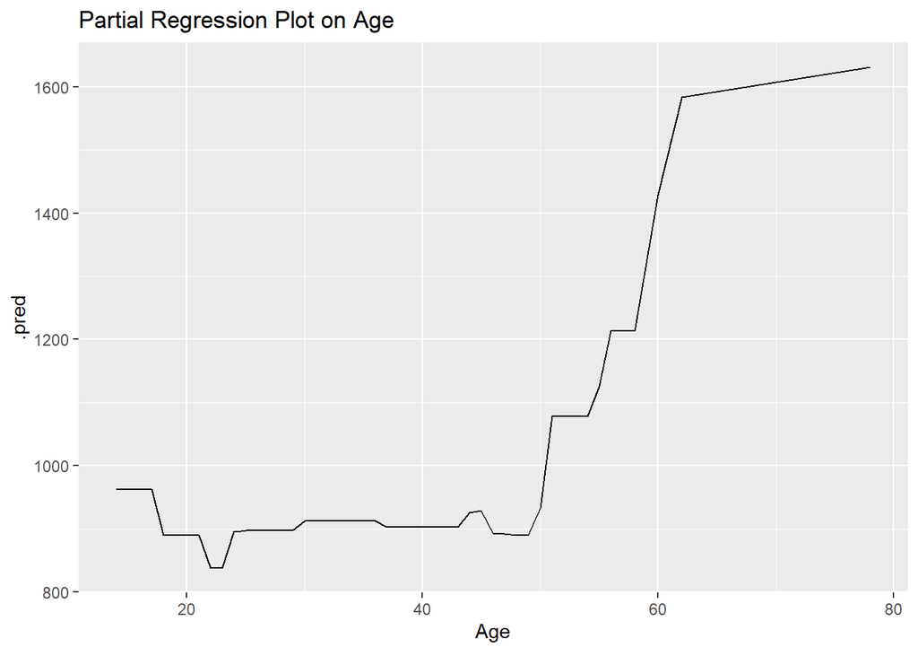

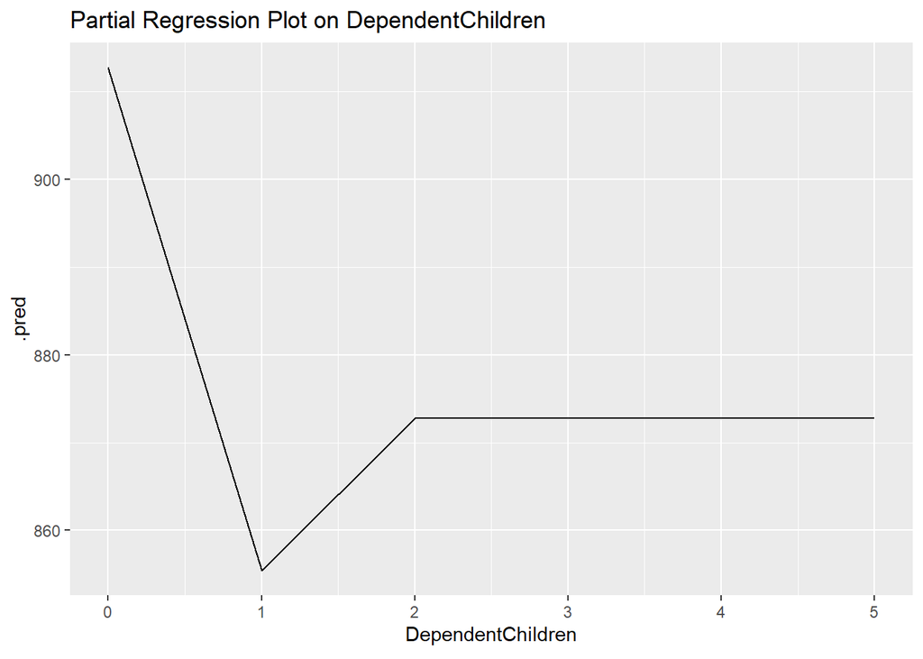

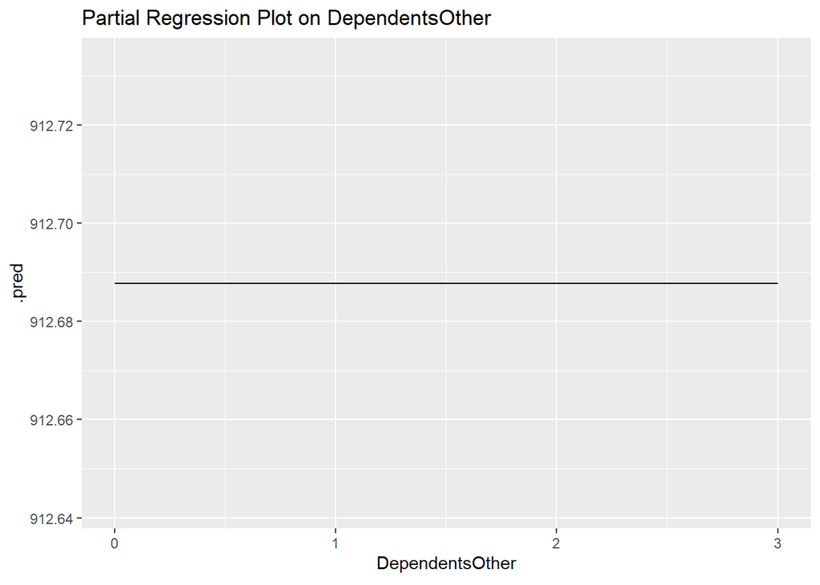

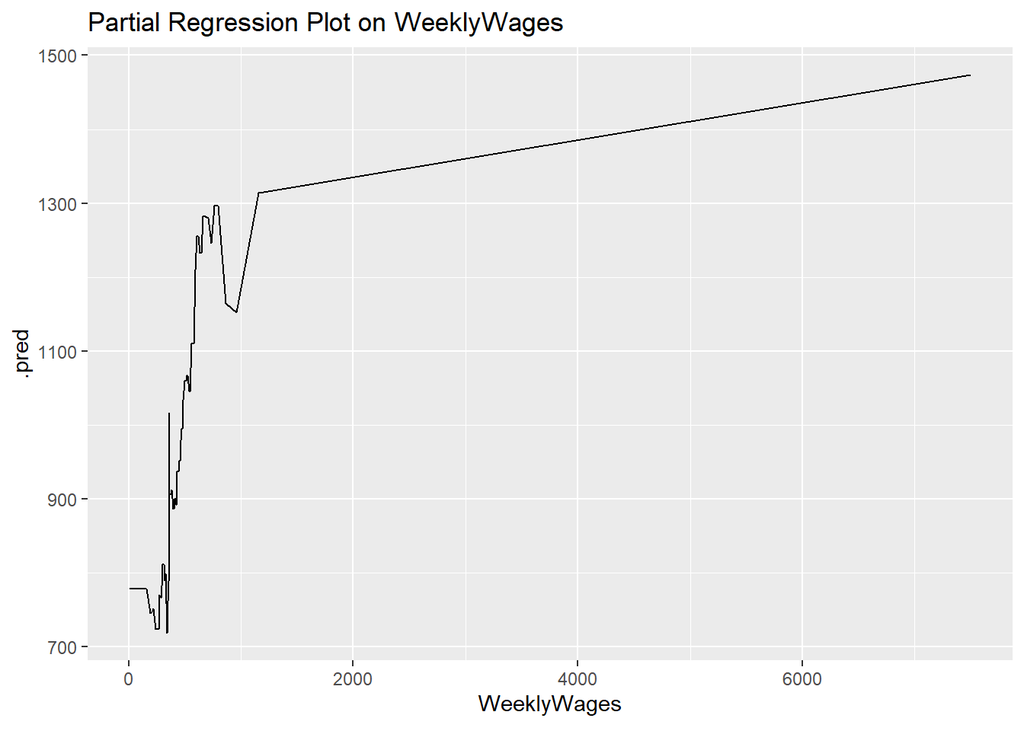

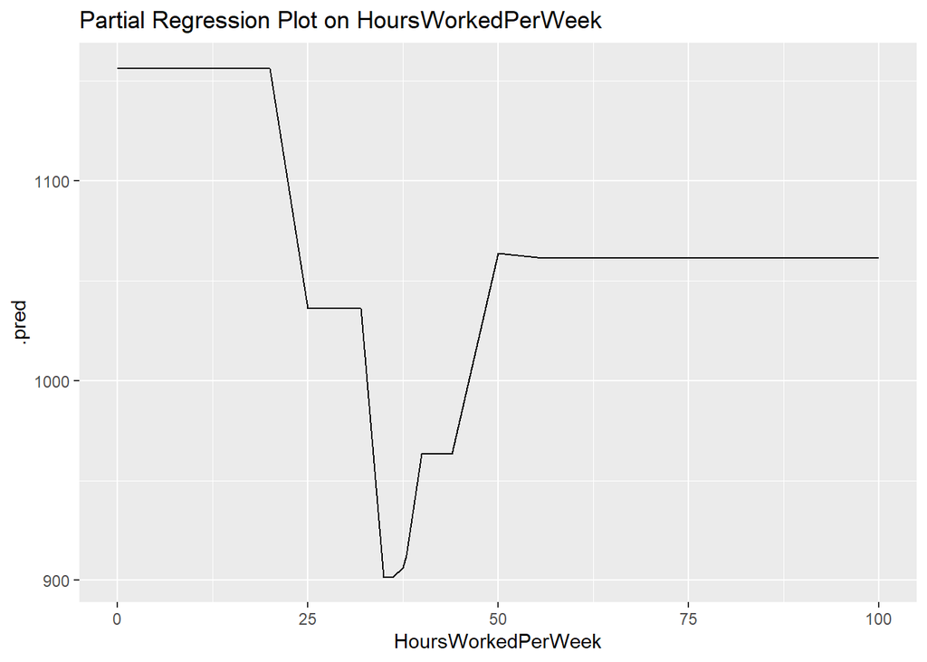

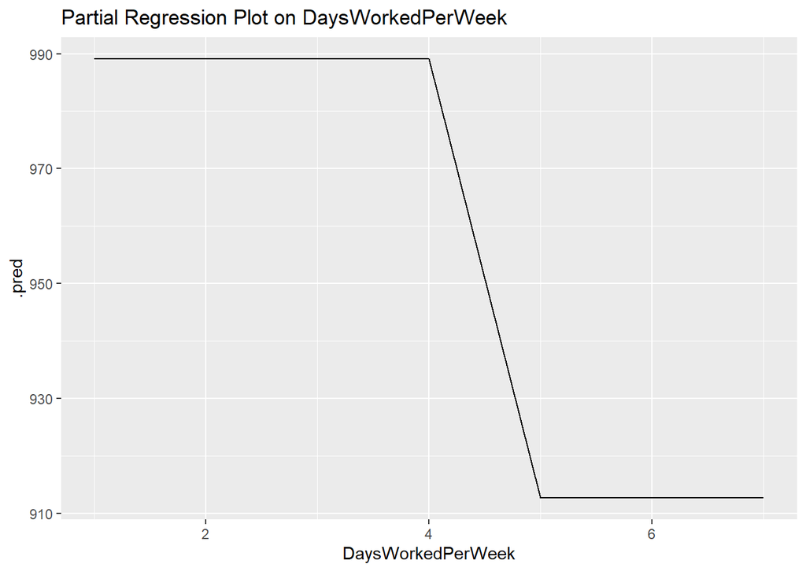

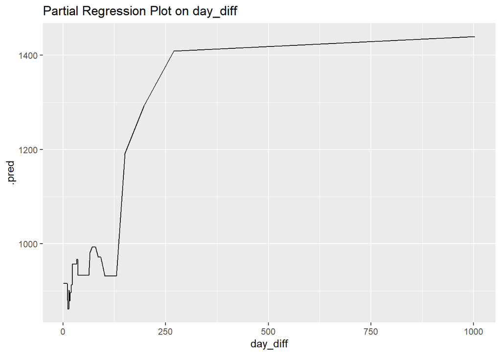

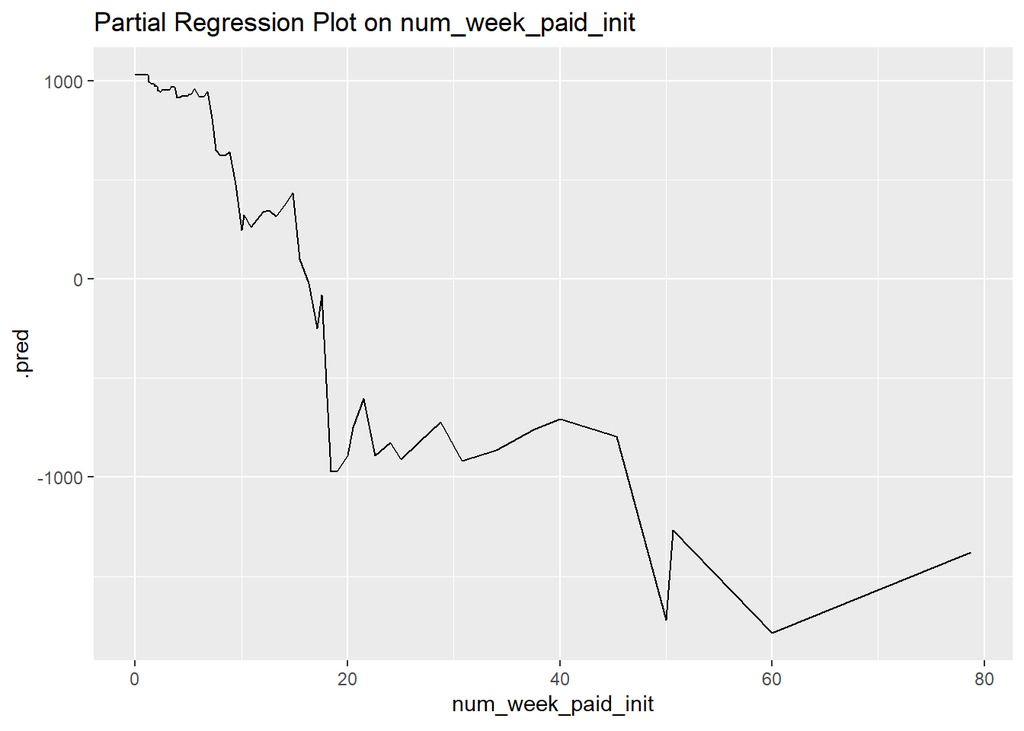

```r
for (i in num_var_list){
  ranger_pdp <-
  recipe(init_ult_diff ~ ., data = df_train) %>%
  step_date(c(DateTimeOfAccident, DateReported)) %>%
  step_mutate(DateTimeOfAccident_hr = lubridate::hour(DateTimeOfAccident),
              DateTimeOfAccident_hr = factor(DateTimeOfAccident_hr, order = TRUE)) %>%
  step_profile(all_predictors(), -sym(i), profile = vars(i)) %>%
  prep() %>%
  juice()

  print(predict(ranger_fit_pdp, ranger_pdp) %>%
  bind_cols(ranger_pdp) %>%
  ggplot(aes(x = get(i), y = .pred)) +
    xlab(sym(i)) +
    labs(title = paste0("Partial Regression Plot on ", sym(i))) +
  geom_path()
  )
}
```